# Oxygen project using eICU data

Willem van den Boom

October 6, 2018

```r
if(!require(bigrquery)) {
  install.packages("bigrquery")
  library("bigrquery")
}
```

```r
# Project ID from Google Cloud
project_id <- "oxygenators-209612"
options(httr_oauth_cache=FALSE)

# Wrapper for running BigQuery queries.
run_query <- function(query){
    data <- query_exec(query, project=project_id, use_legacy_sql = FALSE, max_pages = Inf)
    return(data)
}

# Library for fitting generalized additive models (GAMs)
library(mgcv)
if(!require(mgcv)) {
  install.packages("mgcv")
  library("mgcv")
}
```

# Read in data from eICU

```r
patient <- run_query('
SELECT * FROM eicu.final_patient_results
')

O2measurement <- run_query('
SELECT * FROM eicu.final_measurement_results
')
```

# Data preprocessing

## Gender

Transform gender to a factor rather than string Set genders that are neither male nor female as missing, effectively excluding these from the analysis

```r
if(is.character(patient$gender)) patient$gender_string <- patient$gender
summary(as.factor(patient$gender_string))
```

```
##          Female    Male   Other Unknown
##     134   92303  108379       8      35
```

```r
patient$gender <- NA
patient$gender[patient$gender_string == "Female"] = "F"
patient$gender[patient$gender_string == "Male"] = "M"

patient$gender = as.factor(patient$gender)
```

## ICU type

### From Slack

*Mornin Feng* The followings are my suggestions: 1/ Just exclude Neuro ICUS 2/ Merge “Cardiac ICU” “CCU-CTICU”: Coronary Care Unit / Cardiothoracic ICU “CTICU”: Cardiothoracic ICU as CCUs, BUT keep “CSICU”: Cardiac Surgery ICU separately as CSICU 3/ MICU and SICU should not be merged 4/ Med-Surg ICU, KC See what do you think? (edited)

*KC See* I largely agree with Mornin. The Neuro ICU is unclear what it is - Medical Neuro vs Neurosurgical. For CSICU, I think it is like CTICU. Can we do analysis with and without it, and see if there is a difference? MICU, MSICU, and SICU should be separate. Then if all shows similar results, we can pool everything too

```r
patient$unit_type = as.factor(patient$unittype)

#levels(patient$unit_type)[levels(patient$unit_type) %in% c("Med-Surg ICU", "MICU", "SICU")] = "General ICU"
levels(patient$unit_type)[levels(patient$unit_type) %in% c("CCU-CTICU", "CSICU", "CTICU")] = "Cardiac ICU"
```

## Determine first stay

We use `hospitalDischargeYear` and `unit_stay_number` to determine whether an ICU stay was a patient’s first.

Note that `unit_stay_number` [does not always start at 1](https://github.com/MIT-LCP/eicu-code/issues/16).

```r
patient$first_stay = NA

for(i in 1:max(patient$unit_stay_number)) {
  tmp_table = table(patient$patient_ID[
    patient$unit_stay_number <= i
    & is.na(patient$first_stay)
  ])

  # An ICU stay that is a patient's only one with `unit_stay_number` <= i
  # must be a first stay.
  tmp_index <- patient$patient_ID %in% names(tmp_table)[tmp_table == 1]

  patient$first_stay[
     tmp_index
  ] <- FALSE

  patient$first_stay[
    tmp_index
    & patient$unit_stay_number <= i
  ] <- TRUE
}


# `hospitalDischargeYear` only takes the values 2014 and 2015
unique(patient$hospitalDischargeYear)
```

```
## [1] 2015 2014
```

```r
# The remaning NAs in first_stay can only be resolved if a patient
# has only 1 hospital stay with a discharge in 2014
tmp_IDs <- unique(patient$patient_ID[
  is.na(patient$first_stay)
  & patient$hospitalDischargeYear == 2014
])

for(id in tmp_IDs) {
  tmp_index <- which(
    patient$patient_ID == id &
    patient$hospitalDischargeYear == 2014
  )

  if(length(tmp_index) == 1) {
    patient$first_stay[patient$patient_ID == id] <- FALSE
    patient$first_stay[tmp_index] <- TRUE
  }
}

rm(tmp_table, tmp_index, tmp_IDs, i, id)

summary(patient$first_stay)
```

```
##    Mode   FALSE    TRUE    NA's
## logical   31394  124984   44481
```

```r
length(unique(patient$patient_ID))
```

```
## [1] 139367
```

```r
length(unique(patient$patient_ID[is.na(patient$first_stay)]))
```

```
## [1] 14383
```

# Ventilation times

We determine the ventilation times based on a variety of data tables. We do not use `respiratorycare` since its time stamps [are not recorded correctly](https://github.com/MIT-LCP/eicu-code/issues/49).

In `nursecharting`, we look at the presence of a positive oxygen flow or oxygen admin devices that indicate oxygen therapy. We are only interested in positive oxygen flows. Also, we ignore what happens more than an hour in advance of ICU admission. `respiratorycharting.respchartvaluelabel` sometimes indicates ventilation. All this is contained in the SQL view `oxygen_therapy`.Furthermore, `type` indicates whether the entry suggests invasive ventilation (4), noninvasive ventilation (3), either invasive or noninvasive ventilation (2), supplemental oxygen (1). If the entry does not suggest a type of oxygen therapy, `type = 0`.

```r
oxygen_therapy <- run_query('
SELECT * FROM eicu.oxygen_therapy
')
```

`treatment.treatmentstring` sometimes indicates ventilation. We load its oxygen therapy entries in a seperate view as `treatment` includes `activeUponDischarge` which the other tables do not.

```r
oxygen_therapy_treatment <- run_query('
SELECT * FROM eicu.oxygen_therapy_treatment
')
```

Oxygen flows and respiratorycharting entries are usually recorded every 60 minutes and oxygen administration devices mostly in at most 2 hour intervals but we allow for gaps of up to 24*60 minutes. Treatment is recorded irregularly but mostly more often than every day (24*60 minutes). So, we also allow gaps there.

```r
tmp_IDs <- unique(patient$patientunitstayid[patient$first_stay & !is.na(patient$first_stay)])

# We only keep entries in `oxygen_therapy` and `oxygen_therapy_treatment` that appear in tmp_IDs for computational efficiency.
oxygen_therapy <- oxygen_therapy[oxygen_therapy$icustay_id %in% tmp_IDs,]
oxygen_therapy_treatment <- oxygen_therapy_treatment[oxygen_therapy_treatment$icustay_id %in% tmp_IDs,]

tmp_IDs <- unique(c(oxygen_therapy$icustay_id, oxygen_therapy_treatment$icustay_id))
n <- length(tmp_IDs)

patient$vent_start <- NA_integer_
patient$vent_end <- NA_integer_
patient$oxygen_therapy_type <- NA_integer_

pb <- txtProgressBar(max = n, style = 3)
for(i in 1:n) {
  id <- tmp_IDs[i]
  patient_ind <- which(patient$patientunitstayid == id)

  tmp_treatment <- oxygen_therapy_treatment[oxygen_therapy_treatment$icustay_id == id, -1]
  tmp_therapy <- oxygen_therapy[oxygen_therapy$icustay_id == id, -1]
  times <- sort(c(tmp_therapy$time, tmp_treatment$time))
  patient$vent_start[patient_ind] <- times[1]

  n_times <- length(times)

  breaks <- diff(times) > 60*24

  if(!any(breaks)) {
    patient$vent_end[patient_ind] <- times[n_times]
  } else {
    patient$vent_end[patient_ind] <- times[which(breaks)[1]]
  }

  if(any(tmp_treatment$activeUponDischarge)) {
    last_treatment_time <- min(tmp_treatment$time[which(tmp_treatment$activeUponDischarge)])
    if(last_treatment_time <= patient$vent_end[patient_ind])   {
      patient$vent_end[patient_ind] <- max(
        # The ventilation end time cannot be later/longer than the ICU length of stay
        last_treatment_time,
        24*60*patient$icu_length_of_stay[patient_ind]
      )
    }
  }

  # Determine the oxygen therapy type
  patient$oxygen_therapy_type[patient_ind] <- max(c(
    tmp_therapy$type[tmp_therapy$time >= patient$vent_start[patient_ind] & tmp_therapy$time <= patient$vent_end[patient_ind]],
    tmp_treatment$type[tmp_treatment$time >= patient$vent_start[patient_ind] & tmp_treatment$time <= patient$vent_end[patient_ind]]
  ))

  setTxtProgressBar(pb, i)
}
close(pb)

rm(tmp_IDs, n, id, times, n_times, breaks, i, pb, oxygen_therapy, oxygen_therapy_treatment, last_treatment_time, tmp_treatment, tmp_therapy, patient_ind)

# End time is currently a charting time
# Since these are usually recorded hourly, ventilation is actually longer
patient$vent_end <- patient$vent_end + 60
```

```r
mean(is.na(patient$vent_start))
```

```
## [1] 0.6153371
```

```r
mean(is.na(patient$vent_end))
```

```
## [1] 0.6153371
```

```r
summary(patient$vent_end - patient$vent_start)
```

```
##    Min. 1st Qu.  Median    Mean 3rd Qu.    Max.    NA's
##      60     803    1920    3794    4294  498016  123596
```

```r
mean(patient$vent_end - patient$vent_start >= 60*24, na.rm = TRUE)
```

```
## [1] 0.5949808
```

```r
mean(patient$vent_end - patient$vent_start >= 60*24*2, na.rm = TRUE)
```

```
## [1] 0.3703066
```

```r
mean(patient$vent_end - patient$vent_start >= 60*24*3, na.rm = TRUE)
```

```
## [1] 0.2481654
```

# Oxygen measurements

We remove oxygen measurements that are outside of the range [10, 100]

```r
O2measurement <- O2measurement[O2measurement$spO2_Value <= 100 & O2measurement$spO2_Value >= 10,]
```

Count the number of oxygen measurements per first ventilation of ICU stay Since we only need these counts for the first ICU stay, we constrain ourselves to this subset for speed. We only count measurements that happen during the first oxygen therapy session, and we are only interested in those receiving oxygen for at least 48 hours.

```r
nOxy_limit <- 24

tmp <- unique(O2measurement$icustay_id)
tmp <- tmp[!(tmp %in% patient$icustay_id[patient$first_stay & patient$vent_end - patient$vent_start >= 60*24*2])]
tmp <- table(O2measurement$icustay_id, exclude = tmp)

patient$nOxy <- as.numeric(tmp[match(patient$icustay_id, names(tmp))])
rm(tmp)

# ICU stays that do not have any measurements are currently NA and should be 0.
patient$nOxy[which(is.na(patient$nOxy) & patient$vent_end - patient$vent_start >= 60*24*2)] <- 0


# We've counted all oxygen measurements.
# We should only be counting the measurements that happen during ventilation
tmp_IDs <- patient$icustay_id[which(patient$vent_end - patient$vent_start >= 60*24*2 & patient$nOxy >= nOxy_limit)]
n <- length(tmp_IDs)

# Delete O2measurements that belong to patients that won't be in the selected subset
O2measurement <- O2measurement[O2measurement$icustay_id %in% tmp_IDs,]

index <- match(tmp_IDs, patient$icustay_id)

pb <- txtProgressBar(max = n, style = 3)
for(i in 1:n) {
  ind <- index[i]

  patient$nOxy[ind] <- sum(
    O2measurement$icustay_id == tmp_IDs[i]
    & O2measurement$measurement_time >= patient$vent_start[ind]
    & O2measurement$measurement_time <= patient$vent_end[ind]
  )

  setTxtProgressBar(pb, i)
}
close(pb)
rm(pb, i, index, tmp_IDs, n, ind)
```

```r
mean(patient$nOxy[which(patient$vent_end - patient$vent_start >= 60*24*2)] >= nOxy_limit)
```

```
## [1] 0.369683
```

# Subset selection

The following code selects cases of interest while also providing the info required for a flow diagram: That is, how many patients did not meet the inclusion criteria.

```r
cat("Total number of ICU stays:", nrow(patient))
```

```
## Total number of ICU stays: 200859
```

```r
# We only keep first stays with at least 48 hours of ventilation
tmp <- which(patient$first_stay)
cat("\nNumber of first stays:", length(tmp))
```

```
##
## Number of first stays: 124984
```

```r
cat("\nNumber of patients for whom we couldn't determine first stays:", length(unique(patient$patient_ID[is.na(patient$first_stay)])))
```

```
##
## Number of patients for whom we couldn't determine first stays: 14383
```

```r
tmp <- which(patient$vent_end - patient$vent_start >= 60*24*2)
cat("\nNumber of first ventilations of at least 48 hours:", length(tmp))
```

```
##
## Number of first ventilations of at least 48 hours: 28611
```

```r
patient_subset <- patient[tmp,]



cat("Number of selected patients so far:", nrow(patient_subset))
```

```
## Number of selected patients so far: 28611
```

```r
# Ages above 89 are recorded as "> 89" in the eICU data
# The current SQL code translates "> 89" to "89" such that we cannot distinguish between 89 and >89.
# As we use age as a confounder, we remove those with age 89.
# We only consider "adults" (age >= 16).
tmp <- patient_subset$age < 16 | patient_subset$age == 89
cat("\nPatients outside age range:", sum(tmp, na.rm = TRUE))
```

```
##
## Patients outside age range: 1316
```

```r
cat("\nPatients with missing age:", sum(is.na(tmp)))
```

```
##
## Patients with missing age: 1
```

```r
tmp[is.na(tmp)] <- TRUE

# `delete` records which cases to delete from patient
delete <- tmp

# Delete those whose gender is unknown or other
tmp <- is.na(patient_subset$gender)
cat("\nPatients with missing or 'other' gender:", sum(tmp))
```

```
##
## Patients with missing or 'other' gender: 6
```

```r
delete <- delete | tmp

cat("\nPatients selected so far:", sum(!delete))
```

```
##
## Patients selected so far: 27290
```

```r
# Delete those with fewer than 24 oxygen measurements
tmp <- patient_subset$nOxy < nOxy_limit
cat("\nPatients with too few measurements:", sum(tmp), "out of", nrow(patient_subset))
```

```
##
## Patients with too few measurements: 18034 out of 28611
```

```r
delete <- delete | tmp


patient_subset <- patient_subset[!delete,]
cat("\nPatients selected:", nrow(patient_subset))
```

```
##
## Patients selected: 10184
```

```r
rm(delete)
```

## Cleaning

```r
patient_subset$patientunitstayid <- NULL # Duplicates icustay_id

# Delete O2measurements that belong to patients not in the selected subset
O2measurement <- O2measurement[O2measurement$icustay_id %in% patient_subset$icustay_id,]

# Cases with no diagnoses from ICD-9 codes have all diagnoses as "NA"
# These should be FALSE.
for(j in which(grepl("has_", names(patient_subset)))) {
  patient_subset[is.na(patient_subset[,j]), j] <- FALSE
}
rm(j)
```

## Demographics

Let us compare the demographics before and after the subset selection.

```r
# Variables of which we like summaries
tmp <- c('age', 'gender', 'unit_type', 'nOxy', 'mortality_in_ICU')

cat("Mortality in 'patient':", sum(patient$mortality_in_ICU), "\n")
```

```
## Mortality in 'patient': 10941
```

```r
summary(patient[patient$age >= 16,tmp])
```

```
##       age         gender              unit_type           nOxy
##  Min.   :16.00   F   : 92222   Cardiac ICU : 43522   Min.   :   0.00
##  1st Qu.:53.00   M   :108273   Med-Surg ICU:113004   1st Qu.:   0.00
##  Median :65.00   NA's:   183   MICU        : 17442   Median :   1.00
##  Mean   :63.09                 Neuro ICU   : 14444   Mean   :  84.28
##  3rd Qu.:76.00                 SICU        : 12171   3rd Qu.: 102.00
##  Max.   :89.00                 NA's        :    95   Max.   :4073.00
##  NA's   :95                                          NA's   :172078
##  mortality_in_ICU
##  Min.   :0.0000
##  1st Qu.:0.0000
##  Median :0.0000
##  Mean   :0.0545
##  3rd Qu.:0.0000
##  Max.   :1.0000
##  NA's   :95
```

```r
cat("Mortality in 'patient_subset':", sum(patient_subset$mortality_in_ICU), "\n")
```

```
## Mortality in 'patient_subset': 1155
```

```r
summary(patient_subset[,tmp])
```

```
##       age        gender          unit_type         nOxy
##  Min.   :16.00   F:4497   Cardiac ICU :2768   Min.   :  24.0
##  1st Qu.:54.00   M:5687   Med-Surg ICU:4491   1st Qu.:  87.0
##  Median :65.00            MICU        : 999   Median : 148.0
##  Mean   :62.61            Neuro ICU   :1006   Mean   : 226.5
##  3rd Qu.:74.00            SICU        : 920   3rd Qu.: 269.2
##  Max.   :88.00                                Max.   :4073.0
##  mortality_in_ICU
##  Min.   :0.0000
##  1st Qu.:0.0000
##  Median :0.0000
##  Mean   :0.1134
##  3rd Qu.:0.0000
##  Max.   :1.0000
```

# Compute summaries of oxygen measurements

We compute the median oxygen level and the proportion of measurements within 94% to 97% oxygen saturation. We do this after subset selection as it is much faster to compute these only for the subset of interest.

We currently ignore the time aspect of the measurements. However, one should probably take into account that certain measurements are less spread out than others.

```r
patient_subset$median <- NA
patient_subset$prop <- NA
n <- nrow(patient_subset)
pb <- txtProgressBar(max = n, style = 3)

for(i in 1:n) {
  tmp <- O2measurement$spO2_Value[
    O2measurement$icustay_id == patient_subset$icustay_id[i]
    & O2measurement$measurement_time >= patient_subset$vent_start[i]
    & O2measurement$measurement_time <= patient_subset$vent_end[i]
  ]

  patient_subset$median[i] <- median(tmp)
  patient_subset$prop[i] <- mean(tmp >= 94 & tmp <= 97)

  setTxtProgressBar(pb, i)
}
close(pb)
rm(i,tmp,pb,O2measurement)

summary(patient_subset$median)
summary(patient_subset$prop)
```

[output not shown]

Plot some basic comparison of the two outcome groups.

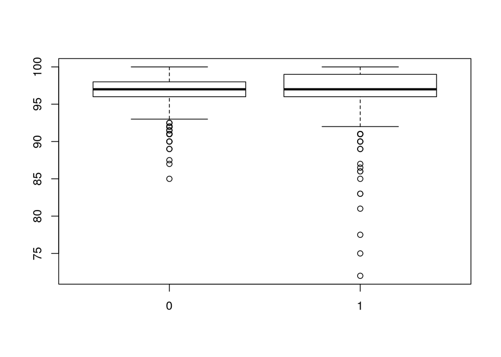

```r
boxplot(patient_subset$median ~ patient_subset$mortality_in_ICU)
```

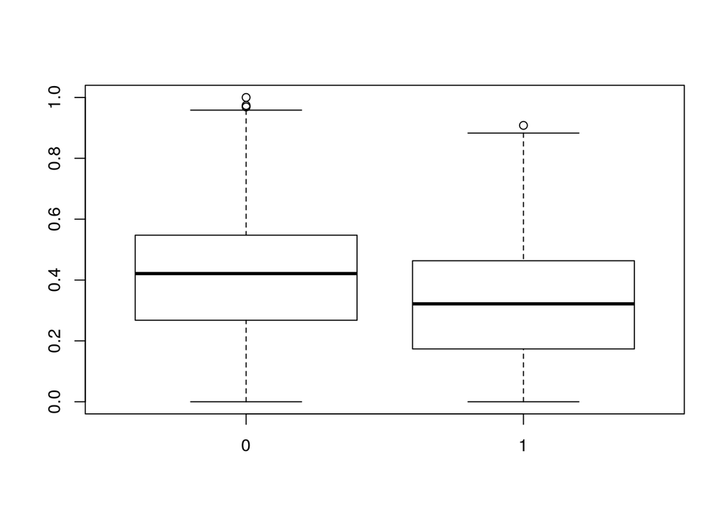

```r
boxplot(patient_subset$prop ~ patient_subset$mortality_in_ICU)
```

# Model fitting

## Median of measurements

```r
logistic <- function(x) 1/(1+exp(-x))

gam_plot <- function(gamfitMed,
                    main = "Median of measurements",
                    xRange = c(92, 100),
                    yRange = c(0, .4)
) {

xlab <- "Median oxygen saturation (SpO2)"
ylab <- "Probability of ICU mortality"

xName <- "median"

# Color for dotted line
colD <- "Black"

    plot(1, type = 'n', xlim = xRange, ylim = yRange,
         ylab = ylab,
         xlab = xlab, main = main, yaxs = 'i', xaxs = 'i', yaxt = 'n', xaxt = 'n')

    att <- pretty(yRange)
if(!isTRUE(all.equal(att, round(att, digits = 2)))) {
  axis(2, at = att, lab = paste0(sprintf('%.1f', att*100), '%'), las = TRUE)
} else axis(2, at = att, lab = paste0(att*100, '%'), las = TRUE)

    att <- pretty(xRange)
    axis(1, at = att, lab = paste0(att, '%'), las = TRUE)


    eval(parse(text = paste(c('predictionsPlusCI <- predict(gamfitMed, newdata = data.frame(',
                              xName, ' = gamfitMed$model$', xName, ", gender = 'F', age = median(gamfitMed$model$age), hospital_id = 264), type = 'link', se.fit = T)"), collapse = "")))


  # We have to use the data on which GAM was fit for confidence region as the GAM does not provide standard errors for 'new' input
  eval(parse(text = paste0('xx <- gamfitMed$model$', xName)))
  ord.index <- order(xx)
  xx <- xx[ord.index]

  if(gamfitMed$family$link == 'logit') {
    lcl <- logistic(predictionsPlusCI$fit[ord.index] - 1.96*predictionsPlusCI$se.fit[ord.index])
    ucl <- logistic(predictionsPlusCI$fit[ord.index] + 1.96*predictionsPlusCI$se.fit[ord.index])

    lines(x = xx, y = lcl, lty = 2, lwd = 2, col = colD)
    lines(x = xx, y = ucl, lty = 2, lwd = 2, col = colD)
    lines(xx, logistic(predictionsPlusCI$fit[ord.index]), lwd = 3)
  } else {
    lcl <- predictionsPlusCI$fit[ord.index] - 1.96*predictionsPlusCI$se.fit[ord.index]
    ucl <- predictionsPlusCI$fit[ord.index] + 1.96*predictionsPlusCI$se.fit[ord.index]

    lines(x = xx, y = lcl, lty = 2, lwd = 2)
    lines(x = xx, y = ucl, lty = 2, lwd = 2)
    lines(xx, predictionsPlusCI$fit[ord.index], lwd = 3)
  }
}

gamfitMed <- gam(mortality_in_ICU ~ s(median)+gender+s(age), data = patient_subset, family = binomial)#gamm(mortality_in_ICU ~ s(median)+gender+s(age), data = patient_subset, family = binomial, random = list(hospital_id = ~ 1))$gam
summary(gamfitMed)
```

```
##
## Family: binomial
## Link function: logit
##
## Formula:
## mortality_in_ICU ~ s(median) + gender + s(age)
##
## Parametric coefficients:
##             Estimate Std. Error z value Pr(>|z|)
## (Intercept) -2.11767    0.04842 -43.737   <2e-16 ***
## genderM      0.04527    0.06384   0.709    0.478
## ---
## Signif. codes:  0 '***' 0.001 '**' 0.01 '*' 0.05 '.' 0.1 ' ' 1
##
## Approximate significance of smooth terms:
##             edf Ref.df  Chi.sq p-value
## s(median) 3.352  4.052 121.952  <2e-16 ***
## s(age)    2.339  2.931   8.874  0.0284 *
## ---
## Signif. codes:  0 '***' 0.001 '**' 0.01 '*' 0.05 '.' 0.1 ' ' 1
##
## R-sq.(adj) =  0.0189   Deviance explained = 2.12%
## UBRE = -0.30628  Scale est. = 1         n = 10184
```

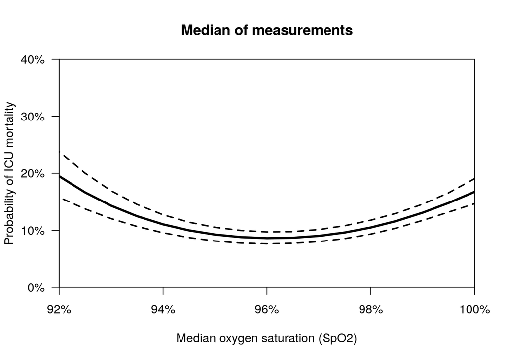

```r
gam_plot(gamfitMed)
```

```r
gamfitMed_type <- gam(mortality_in_ICU ~ s(median)+gender+s(age), data = patient_subset[patient_subset$oxygen_therapy_type == 1,], family = binomial)
summary(gamfitMed_type)
```

```
##
## Family: binomial
## Link function: logit
##
## Formula:
## mortality_in_ICU ~ s(median) + gender + s(age)
##
## Parametric coefficients:
##             Estimate Std. Error z value Pr(>|z|)
## (Intercept)  -4.1666     0.4615  -9.028   <2e-16 ***
## genderM      -0.7126     0.7195  -0.991    0.322
## ---
## Signif. codes:  0 '***' 0.001 '**' 0.01 '*' 0.05 '.' 0.1 ' ' 1
##
## Approximate significance of smooth terms:
##             edf Ref.df Chi.sq p-value
## s(median) 2.906  3.617  2.642   0.555
## s(age)    1.000  1.000  0.217   0.641
##
## R-sq.(adj) =  0.00195   Deviance explained = 5.87%
## UBRE = -0.84938  Scale est. = 1         n = 676
```

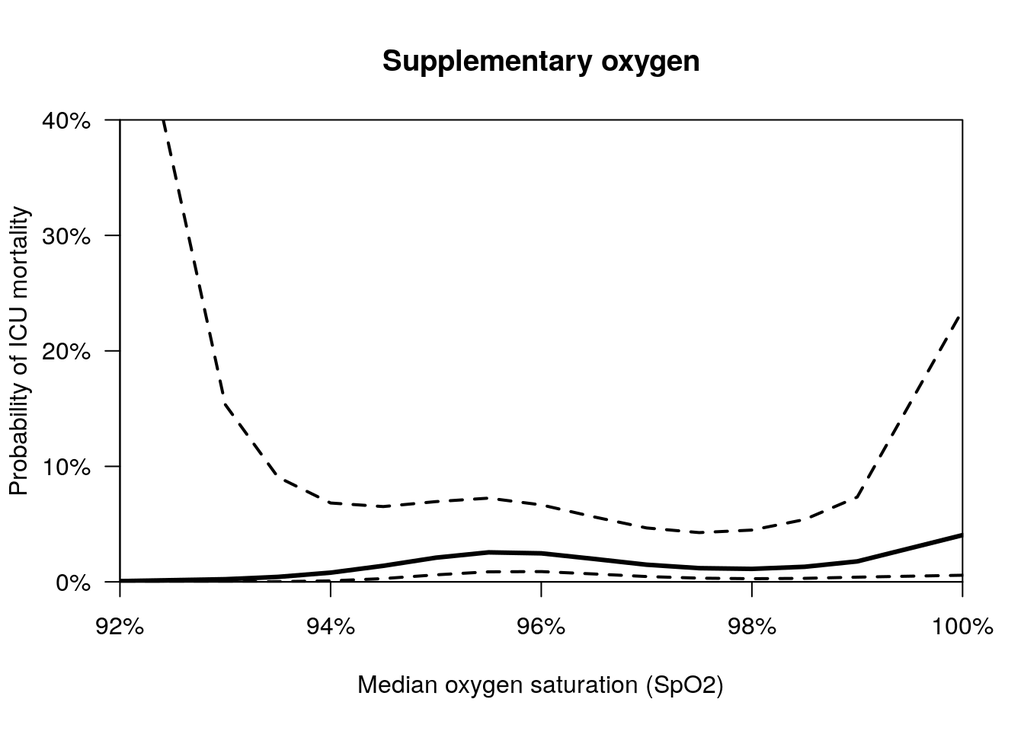

```r
gam_plot(gamfitMed_type, main = "Supplementary oxygen")
```

```r
gamfitMed_type <- gam(mortality_in_ICU ~ s(median)+gender+s(age), data = patient_subset[patient_subset$oxygen_therapy_type >= 2,], family = binomial)
summary(gamfitMed_type)
```

```
##
## Family: binomial
## Link function: logit
##
## Formula:
## mortality_in_ICU ~ s(median) + gender + s(age)
##
## Parametric coefficients:
##             Estimate Std. Error z value Pr(>|z|)
## (Intercept) -1.94776    0.04965 -39.232   <2e-16 ***
## genderM      0.01861    0.06528   0.285    0.776
## ---
## Signif. codes:  0 '***' 0.001 '**' 0.01 '*' 0.05 '.' 0.1 ' ' 1
##
## Approximate significance of smooth terms:
##             edf Ref.df Chi.sq  p-value
## s(median) 3.316  4.023 102.41  < 2e-16 ***
## s(age)    1.005  1.010  14.56 0.000139 ***
## ---
## Signif. codes:  0 '***' 0.001 '**' 0.01 '*' 0.05 '.' 0.1 ' ' 1
##
## R-sq.(adj) =  0.0192   Deviance explained = 2.03%
## UBRE = -0.24343  Scale est. = 1         n = 8712
```

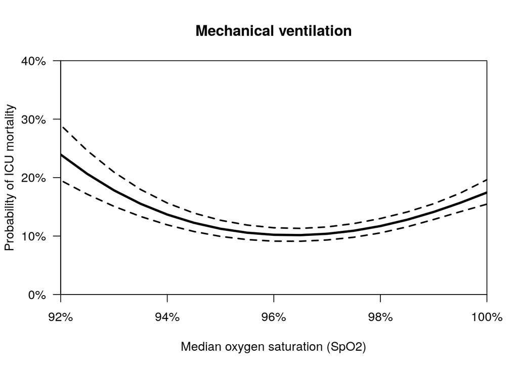

```r
gam_plot(gamfitMed_type, main = "Mechanical ventilation")
```

```r
gamfitMed_type <- gam(mortality_in_ICU ~ s(median)+gender+s(age), data = patient_subset[patient_subset$oxygen_therapy_type == 3,], family = binomial)
summary(gamfitMed_type)
```

```
##
## Family: binomial
## Link function: logit
##
## Formula:
## mortality_in_ICU ~ s(median) + gender + s(age)
##
## Parametric coefficients:
##             Estimate Std. Error z value Pr(>|z|)
## (Intercept)  -2.5514     0.1801 -14.168   <2e-16 ***
## genderM       0.2572     0.2269   1.134    0.257
## ---
## Signif. codes:  0 '***' 0.001 '**' 0.01 '*' 0.05 '.' 0.1 ' ' 1
##
## Approximate significance of smooth terms:
##             edf Ref.df Chi.sq p-value
## s(median) 4.662  5.452 16.922 0.00529 **
## s(age)    1.310  1.559  3.658 0.07286 .
## ---
## Signif. codes:  0 '***' 0.001 '**' 0.01 '*' 0.05 '.' 0.1 ' ' 1
##
## R-sq.(adj) =  0.0571   Deviance explained = 6.38%
## UBRE = -0.42539  Scale est. = 1         n = 1074
```

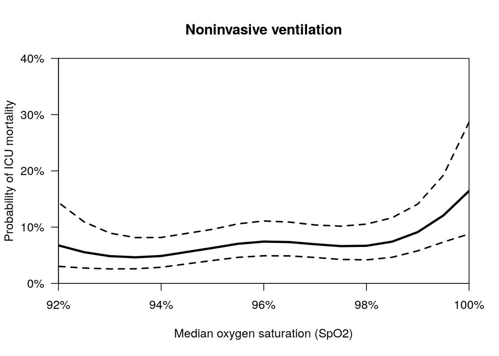

```r
gam_plot(gamfitMed_type, main = "Noninvasive ventilation")
```

```r
gamfitMed_type <- gam(mortality_in_ICU ~ s(median)+gender+s(age), data = patient_subset[patient_subset$oxygen_therapy_type == 4,], family = binomial)
summary(gamfitMed_type)
```

```
##
## Family: binomial
## Link function: logit
##
## Formula:
## mortality_in_ICU ~ s(median) + gender + s(age)
##
## Parametric coefficients:
##             Estimate Std. Error z value Pr(>|z|)
## (Intercept) -1.88148    0.05445 -34.554   <2e-16 ***
## genderM     -0.02481    0.07166  -0.346    0.729
## ---
## Signif. codes:  0 '***' 0.001 '**' 0.01 '*' 0.05 '.' 0.1 ' ' 1
##
## Approximate significance of smooth terms:
##             edf Ref.df Chi.sq  p-value
## s(median) 3.824  4.678  97.92  < 2e-16 ***
## s(age)    2.577  3.228  17.80 0.000723 ***
## ---
## Signif. codes:  0 '***' 0.001 '**' 0.01 '*' 0.05 '.' 0.1 ' ' 1
##
## R-sq.(adj) =  0.0216   Deviance explained = 2.28%
## UBRE = -0.22488  Scale est. = 1         n = 7019
```

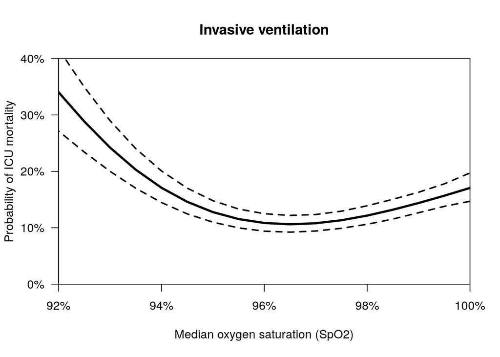

```r
gam_plot(gamfitMed_type, main = "Invasive ventilation")
```

## Proportion of measurements within range

We now fit a GAM with the proportion of measurements within a range instead of the median of the measurements.

```r
gam_plot <- function(gamfitProp, main = "Effect of treatment regime"){
xRange = c(0, max(patient_subset$prop, na.rm= TRUE))
yRange = c(0, .3)

xlab <- "Proportion of time with an SpO2 within 94 to 97"
ylab <- "Probability of ICU mortality"

xName <- "prop"

    plot(1, type = 'n', xlim = xRange, ylim = yRange,
         ylab = ylab,
         xlab = xlab, main = main, yaxs = 'i', xaxs = 'i', yaxt = 'n', xaxt = 'n')

    att <- pretty(yRange)
if(!isTRUE(all.equal(att, round(att, digits = 2)))) {
  axis(2, at = att, lab = paste0(sprintf('%.1f', att*100), '%'), las = TRUE)
} else axis(2, at = att, lab = paste0(att*100, '%'), las = TRUE)

    att <- pretty(xRange)
    axis(1, at = att, lab = paste0(att*100, '%'), las = TRUE)


    eval(parse(text = paste(c('predictionsPlusCI <- predict(gamfitProp, newdata = data.frame(',
                              xName, ' = gamfitProp$model$', xName, ", gender = 'F', age = median(gamfitProp$model$age)), type = 'link', se.fit = T)"), collapse = "")))


  # We have to use the data on which GAM was fit for confidence region as the GAM does not provide standard errors for 'new' input
  eval(parse(text = paste0('xx <- gamfitProp$model$', xName)))
  ord.index <- order(xx)
  xx <- xx[ord.index]

  if(gamfitProp$family$link == 'logit') {
    lcl <- logistic(predictionsPlusCI$fit[ord.index] - 1.96*predictionsPlusCI$se.fit[ord.index])
    ucl <- logistic(predictionsPlusCI$fit[ord.index] + 1.96*predictionsPlusCI$se.fit[ord.index])

    lines(x = xx, y = lcl, lty = 2, lwd = 2)
    lines(x = xx, y = ucl, lty = 2, lwd = 2)
    lines(xx, logistic(predictionsPlusCI$fit[ord.index]), lwd = 3)
  } else {
    lcl <- predictionsPlusCI$fit[ord.index] - 1.96*predictionsPlusCI$se.fit[ord.index]
    ucl <- predictionsPlusCI$fit[ord.index] + 1.96*predictionsPlusCI$se.fit[ord.index]

    lines(x = xx, y = lcl, lty = 2, lwd = 2)
    lines(x = xx, y = ucl, lty = 2, lwd = 2)
    lines(xx, predictionsPlusCI$fit[ord.index], lwd = 3)
  }
}

gamfitProp <- gam(mortality_in_ICU ~ s(prop)+gender+s(age), data = patient_subset, family = binomial)#gamm(mortality_in_ICU ~ s(prop)+gender+s(age), data = patient_subset, family = binomial, random = list(hospital_id = ~ 1))$gam
summary(gamfitProp)
```

```
##
## Family: binomial
## Link function: logit
##
## Formula:
## mortality_in_ICU ~ s(prop) + gender + s(age)
##
## Parametric coefficients:
##             Estimate Std. Error z value Pr(>|z|)
## (Intercept) -2.17557    0.04957 -43.885   <2e-16 ***
## genderM      0.07309    0.06396   1.143    0.253
## ---
## Signif. codes:  0 '***' 0.001 '**' 0.01 '*' 0.05 '.' 0.1 ' ' 1
##
## Approximate significance of smooth terms:
##           edf Ref.df Chi.sq p-value
## s(prop) 1.005  1.009 194.01 < 2e-16 ***
## s(age)  2.615  3.272  13.38 0.00534 **
## ---
## Signif. codes:  0 '***' 0.001 '**' 0.01 '*' 0.05 '.' 0.1 ' ' 1
##
## R-sq.(adj) =  0.0206   Deviance explained = 2.88%
## UBRE = -0.31205  Scale est. = 1         n = 10184
```

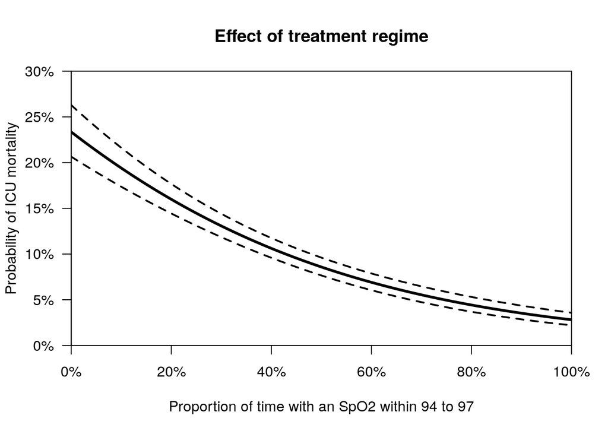

```r
gam_plot(gamfitProp)
```

```r
gamfitProp_type <- gam(mortality_in_ICU ~ s(prop)+gender+s(age), data = patient_subset[patient_subset$oxygen_therapy_type == 1,], family = binomial)
summary(gamfitProp_type)
```

```
##
## Family: binomial
## Link function: logit
##
## Formula:
## mortality_in_ICU ~ s(prop) + gender + s(age)
##
## Parametric coefficients:
##             Estimate Std. Error z value Pr(>|z|)
## (Intercept)  -4.0476     0.4259  -9.504   <2e-16 ***
## genderM      -0.6721     0.7165  -0.938    0.348
## ---
## Signif. codes:  0 '***' 0.001 '**' 0.01 '*' 0.05 '.' 0.1 ' ' 1
##
## Approximate significance of smooth terms:
##         edf Ref.df Chi.sq p-value
## s(prop)   1      1  0.132   0.717
## s(age)    1      1  0.199   0.655
##
## R-sq.(adj) =  -0.00255   Deviance explained =  1.5%
## UBRE = -0.84883  Scale est. = 1         n = 676
```

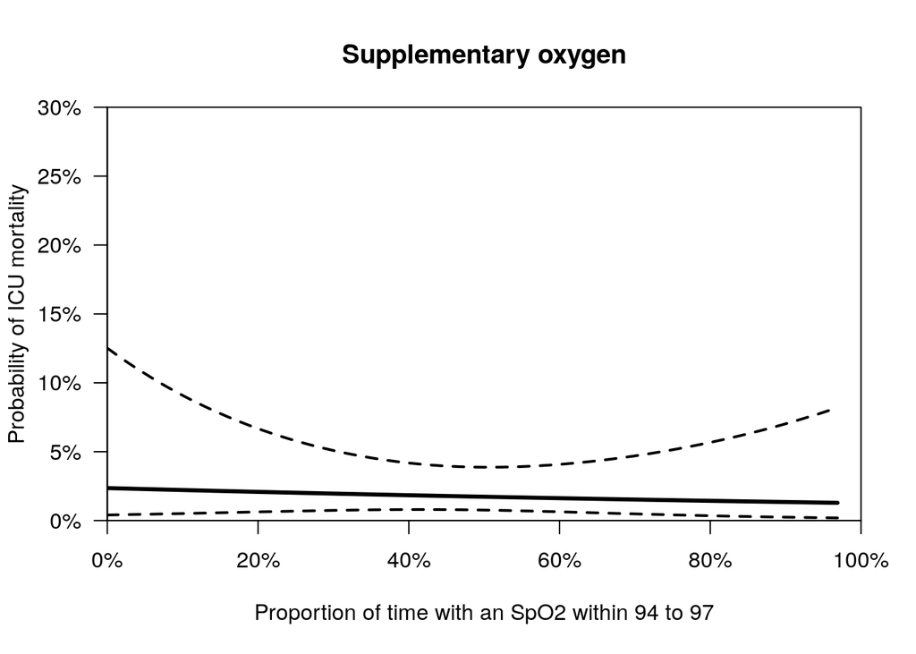

```r
gam_plot(gamfitProp_type, main = "Supplementary oxygen")
```

```r
gamfitProp_type <- gam(mortality_in_ICU ~ s(prop)+gender+s(age), data = patient_subset[patient_subset$oxygen_therapy_type >= 2,], family = binomial)
summary(gamfitProp_type)
```

```
##
## Family: binomial
## Link function: logit
##
## Formula:
## mortality_in_ICU ~ s(prop) + gender + s(age)
##
## Parametric coefficients:
##             Estimate Std. Error z value Pr(>|z|)
## (Intercept) -1.99747    0.05061 -39.471   <2e-16 ***
## genderM      0.05330    0.06536   0.816    0.415
## ---
## Signif. codes:  0 '***' 0.001 '**' 0.01 '*' 0.05 '.' 0.1 ' ' 1
##
## Approximate significance of smooth terms:
##           edf Ref.df Chi.sq p-value
## s(prop) 1.005  1.010 145.91 < 2e-16 ***
## s(age)  2.404  3.012  20.19 0.00016 ***
## ---
## Signif. codes:  0 '***' 0.001 '**' 0.01 '*' 0.05 '.' 0.1 ' ' 1
##
## R-sq.(adj) =  0.0186   Deviance explained = 2.43%
## UBRE = -0.24671  Scale est. = 1         n = 8712
```

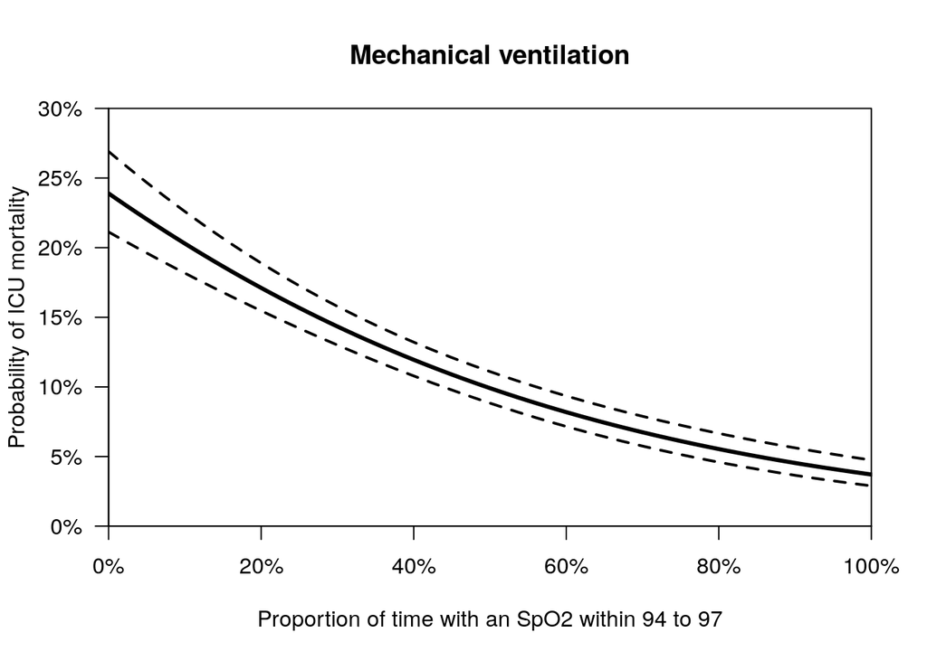

```r
gam_plot(gamfitProp_type, main = "Mechanical ventilation")
```

```r
gamfitProp_type <- gam(mortality_in_ICU ~ s(prop)+gender+s(age), data = patient_subset[patient_subset$oxygen_therapy_type == 3,], family = binomial)
summary(gamfitProp_type)
```

```
##
## Family: binomial
## Link function: logit
##
## Formula:
## mortality_in_ICU ~ s(prop) + gender + s(age)
##
## Parametric coefficients:
##             Estimate Std. Error z value Pr(>|z|)
## (Intercept)  -2.5986     0.1764 -14.733   <2e-16 ***
## genderM       0.3032     0.2215   1.369    0.171
## ---
## Signif. codes:  0 '***' 0.001 '**' 0.01 '*' 0.05 '.' 0.1 ' ' 1
##
## Approximate significance of smooth terms:
##           edf Ref.df Chi.sq  p-value
## s(prop) 1.002  1.004 16.827 4.13e-05 ***
## s(age)  1.370  1.655  3.104    0.107
## ---
## Signif. codes:  0 '***' 0.001 '**' 0.01 '*' 0.05 '.' 0.1 ' ' 1
##
## R-sq.(adj) =   0.02   Deviance explained = 3.54%
## UBRE = -0.41516  Scale est. = 1         n = 1074
```

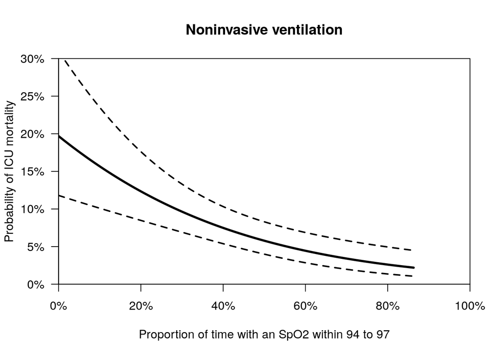

```r
gam_plot(gamfitProp_type, main = "Noninvasive ventilation")
```

```r
gamfitProp_type <- gam(mortality_in_ICU ~ s(prop)+gender+s(age), data = patient_subset[patient_subset$oxygen_therapy_type == 4,], family = binomial)
summary(gamfitProp_type)
```

```
##
## Family: binomial
## Link function: logit
##
## Formula:
## mortality_in_ICU ~ s(prop) + gender + s(age)
##
## Parametric coefficients:
##              Estimate Std. Error z value Pr(>|z|)
## (Intercept) -1.918000   0.055153 -34.776   <2e-16 ***
## genderM      0.005802   0.071511   0.081    0.935
## ---
## Signif. codes:  0 '***' 0.001 '**' 0.01 '*' 0.05 '.' 0.1 ' ' 1
##
## Approximate significance of smooth terms:
##           edf Ref.df Chi.sq  p-value
## s(prop) 1.526  1.894 104.92  < 2e-16 ***
## s(age)  2.732  3.418  20.76 0.000236 ***
## ---
## Signif. codes:  0 '***' 0.001 '**' 0.01 '*' 0.05 '.' 0.1 ' ' 1
##
## R-sq.(adj) =  0.0168   Deviance explained = 2.22%
## UBRE = -0.22507  Scale est. = 1         n = 7019
```

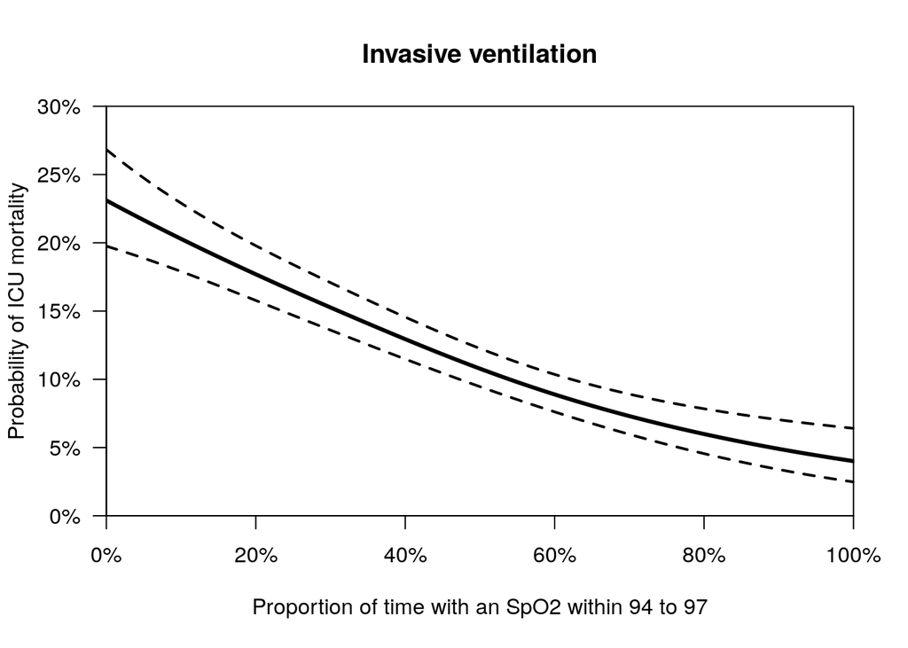

```r
gam_plot(gamfitProp_type, main = "Invasive ventilation")
```

## Odds ratios

Based on the model fits, we can estimate odds ratios, including 95% confidence intervals.

```r
if(!require("oddsratio")) {
  install.packages("oddsratio")
  library(oddsratio)
}
tmp <- or_gam(data = patient_subset, model = gamfitMed, pred = "median", values = c(96, 100))

cat(
  "The odds ratio of mortality for a median oxygen saturation at 100% versus 96% is ",
  tmp$oddsratio,
  " (95% CI ",
  tmp$`CI_high (97.5%)`,
  " to ",
  tmp$`CI_low (2.5%)`,
  ").",
  sep = ""
)
```

[output not shown]

```r
tmp <- or_gam(data = patient_subset, model = gamfitProp, pred = "prop", values = c(.8, .4))

cat(
  "The odds ratio of mortality for a proportion of measurements within the range at 40% versus 80% is ",
  tmp$oddsratio,
  " (95% CI ",
  tmp$`CI_low (2.5%)`,
  " to ",
  tmp$`CI_high (97.5%)`,
  ").",
  sep = ""
)
```

```
## The odds ratio of mortality for a proportion of measurements within the range at 40% versus 80% is 2.565607 (95% CI 2.374357 to 2.772263).
```